# HMW4_NWANEGBO

NWANEGBO

2022-10-29

## IMPORT THE DATA

```r
y <- read.csv("MYMALES.csv")
y
```

```
##   Year Age.group Males.Estonia
## 1 2013     30-34           172
## 2 2014     30-34           197
## 3 2015     30-34           717
## 4 2016     30-34           647
## 5 2017     30-34           714
## 6 2018     30-34           657
## 7 2019     30-34           618
## 8 2020     30-34           458
## 9 2021     30-34           578
```

```r
y <- y[ ,-2]
y
```

```
##   Year Males.Estonia
## 1 2013           172
## 2 2014           197
## 3 2015           717
## 4 2016           647
## 5 2017           714
## 6 2018           657
## 7 2019           618
## 8 2020           458
## 9 2021           578
```

2. Prepare EDA (Explanatory Data Analysis). Write at least 5 questions and provide your answers during the first stage of EDA.

do i need to clean my data, does it have any null values or outliers that might affect my graphical analysis

The data being analysed is a sample of Estonian males immigrants that falls in age range of 30-34 within the year 2013 to 2021

The data set consists of two variables with column 1 having the year, column 2 population of male immigrants in Estonia

i actually had to clean my data because the initial second coloumn had the same age for all the years in the data

Firstly i need to identify what kind of data this, this is a continuous data.

(You can check the slides from Session 5 - Data Exploration (EDA) for ideas or come up with your own questions).

to check the first 6 rows of my data i would use the head() function

```r
head(y)
```

```
##   Year Males.Estonia
## 1 2013           172
## 2 2014           197
## 3 2015           717
## 4 2016           647
## 5 2017           714
## 6 2018           657
```

to check the last 6 rows of my_data i would use the tail() function

```r
tail(y)
```

```
##   Year Males.Estonia
## 4 2016           647
## 5 2017           714
## 6 2018           657
## 7 2019           618
## 8 2020           458
## 9 2021           578
```

to check the structure of my_data i would use the str()

```r
str(y)
```

```
## 'data.frame':    9 obs. of  2 variables:
##  $ Year         : int  2013 2014 2015 2016 2017 2018 2019 2020 2021
##  $ Males.Estonia: int  172 197 717 647 714 657 618 458 578
```

this gives me on R 9 observations and 2 variables.

3. Provide brief descriptive statistical analysis of your data set (like measures of central tendency and dispersion).

```r
mean(y[,2])
```

```
## [1] 528.6667
```

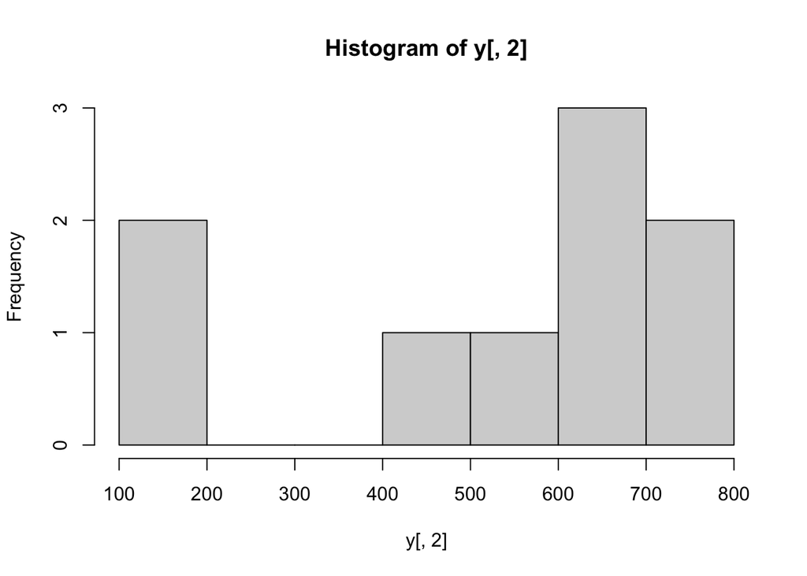

```r
hist(y[,2])
```

```r
median(y[,2])
```

```
## [1] 618
```

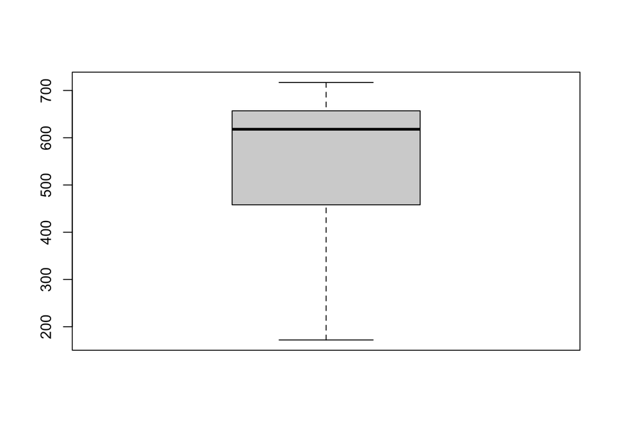

```r
boxplot(y[,2])
```

4. Include at least one plot into your report. If ggplot2 is too complicated for you now, create a plot with R base functions.